# Homework 3

Yuvraj Jain

February 17, 2023

# Instructions

**Exercises:** 1,3 (Pgs. 90-91); 1 (Pg. 93); 2,4 (Pg. 99); 1,2 (Pg. 101); 2,3,5 (Pg. 104)

**Submission:** Submit via an electronic document on Sakai. Must be submitted as a HTML file generated in RStudio. All assigned problems are chosen according to the textbook *R for Data Science*. You do not need R code to answer every question. If you answer without using R code, delete the code chunk. If the question requires R code, make sure you display R code. If the question requires a figure, make sure you display a figure. A lot of the questions can be answered in written response, but require R code and/or figures for understanding and explaining.

# Chapter 5 (Pgs. 90-91)

## Exercise 1:

Explore the distribution of each of the `x`, `y`, and `z` variables in diamonds. What do you learn? Think about a diamond and how you might decide which dimension is the length, width, and depth.

```r
summary(diamonds)
```

```
##      carat               cut        color        clarity          depth
##  Min.   :0.2000   Fair     : 1610   D: 6775   SI1    :13065   Min.   :43.00
##  1st Qu.:0.4000   Good     : 4906   E: 9797   VS2    :12258   1st Qu.:61.00
##  Median :0.7000   Very Good:12082   F: 9542   SI2    : 9194   Median :61.80
##  Mean   :0.7979   Premium  :13791   G:11292   VS1    : 8171   Mean   :61.75
##  3rd Qu.:1.0400   Ideal    :21551   H: 8304   VVS2   : 5066   3rd Qu.:62.50
##  Max.   :5.0100                     I: 5422   VVS1   : 3655   Max.   :79.00
##                                     J: 2808   (Other): 2531
##      table           price             x                y
##  Min.   :43.00   Min.   :  326   Min.   : 0.000   Min.   : 0.000
##  1st Qu.:56.00   1st Qu.:  950   1st Qu.: 4.710   1st Qu.: 4.720
##  Median :57.00   Median : 2401   Median : 5.700   Median : 5.710
##  Mean   :57.46   Mean   : 3933   Mean   : 5.731   Mean   : 5.735
##  3rd Qu.:59.00   3rd Qu.: 5324   3rd Qu.: 6.540   3rd Qu.: 6.540
##  Max.   :95.00   Max.   :18823   Max.   :10.740   Max.   :58.900
##
##        z
##  Min.   : 0.000
##  1st Qu.: 2.910
##  Median : 3.530
##  Mean   : 3.539
##  3rd Qu.: 4.040
##  Max.   :31.800
##
```

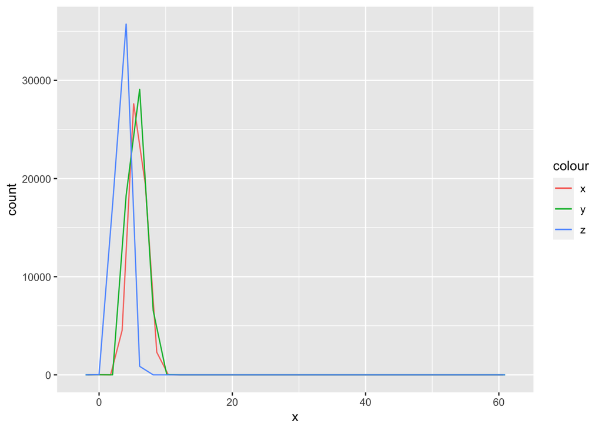

```r
ggplot(data = diamonds) +
  geom_freqpoly(mapping = aes(x, color = "x"), bins = 35) +
  geom_freqpoly(mapping = aes(y, color = "y"), bins = 30) +
  geom_freqpoly(mapping = aes(z, color = "z"), bins = 30)
```

From the above summary and the frequency graph, we can se that x and y more or less have a similar graph sharing their range, while z has a considerably lower value compared to x and y. The documentation tells us that `x` is the length, `y` is the width, and the `z` is the depth. This makes sense because depth should be less than length and width.

## Exercise 3:

How many diamonds are 0.99 carat? How many are 1 carat? What do you think is the cause of the difference?

```r
diamonds %>%
  filter(carat == 0.99 | carat == 1) %>%
  count(carat)
```

```
## # A tibble: 2 × 2
##   carat     n
##   <dbl> <int>
## 1  0.99    23
## 2  1     1558
```

There are only 23 0.99 carat diamonds, and 1558 1.00 carat diamonds. I think the cause of this difference is because 1.00 is a nice whole number, and most jewellers would just round 0.99 up to 1.00

# Chapter 5 (Pg. 93)

## Exercise 1:

What happens to missing values in a histogram? What happens to missing values in a bar chart? Why is there a difference?

In the `geom_bar()` function, NA is treated as a category and a bar is made for these NA values because they can be treated as a discrete variable. Therefore, they are preserved in a bar chart as a discrete variable.

However, in a histogram, we need numerical values, and NA’s cannot be assigned any particular numeric value, so they are just dropped since they cannot be placed in any particular bin.